# Physical Effort Shifts the Criterion for a Different Judgment in Older Adults

# 1 Introduction

People routinely make perceptual judgments while holding a physical effort. Aging raises the cost of doing both at once (Pashler, 1994; Salthouse, 1996; Verhaeghen et al., 2003; Wickens, 2008). A natural question is which part of the judgment changes. The sensory evidence can become less precise, which flattens the psychometric function. Or the person can require more evidence before calling two stimuli different, which shifts the function without flattening it (Macmillan & Creelman, 2005; Prins et al., 2016).

Pupil diameter is one way to ask whether arousal is the route. Baseline diameter and the task-evoked pupil response both covary with arousal-related neuromodulation (Aston-Jones & Cohen, 2005; Beatty, 1982). They do not, by themselves, separate a change in sensitivity from a change in criterion. That separation comes from the psychometric function.

This chapter asks two questions in older adults who made same–different judgments while holding a low or a high isometric grip. The first is behavioral: does the grip change the criterion for “different,” the slope, or both? The second is physiological: does pupil diameter, either before the probe or in the task-evoked window, track that slope from trial to trial?

The behavioral result in this cohort has already been reported with per-participant psychometric functions (Sun et al., 2026). High grip raised thresholds and did not change slopes, which that paper reads as a more conservative criterion for “different.” This chapter does not repeat that test. Its own behavioral test is a trial-level probit model on the same cleaned trials. The pupil tests are new. They were specified before the present fits were opened, in a locked analysis plan. The study was not pre-registered.

# 2 Methods

## 2.1 Participants and trials

Pupil analyses use a subset of the same trials. A trial entered the pupil file only when a December 21 recording existed and the sample count and within-trial time step met the checks below. The grip-window model uses 5,240 trials (48 participants). The task-evoked models use 6,299 trials (51 participants; 36 auditory, 41 visual). The missingness model uses the 12,630 trials that could be matched to a pupil recording (61 participants), of which 6,299 passed the task-evoked gate.

## 2.2 Task

Participants completed an auditory and a visual same–different task in the scanner, one task per session, order counterbalanced. On each trial they held a left-hand grip at 5% or 40% of maximum voluntary contraction, saw or heard a standard and then a probe, judged whether the two were the same or different, and rated confidence. The inter-trial interval was 1.5–4.5 s (Sun et al., 2026). Figure 1 shows the fixed sequence after squeeze onset. From squeeze onset, the standard began at 3.75 s and the probe at 4.35 s. Grip release was cued at 4.45 s. The same–different response window ran from 4.70 to 7.70 s, and the confidence window followed.

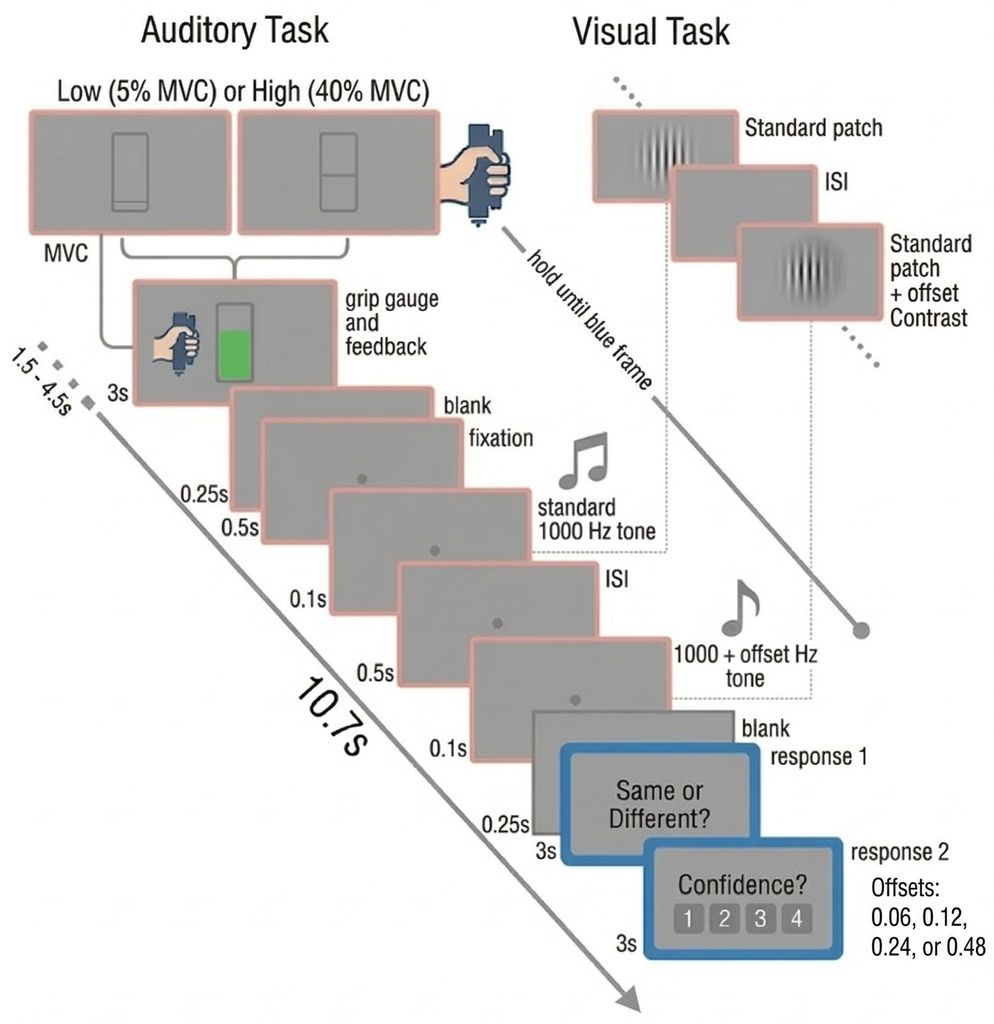

Figure 1: Trial sequence for the auditory and visual same–different tasks. The inter-trial interval is 1.5–4.5 s. Times after squeeze onset follow the schematic. Low effort is 5% MVC and high effort is 40% MVC.

Auditory probes were 1000 Hz or 1000 Hz plus 8, 16, 32, or 64 Hz. Visual probes matched a standard Gabor or raised its contrast by 0.06, 0.12, 0.24, or 0.48. The zero-offset trials are catch trials: the standard and the probe were the same.

Stimuli were presented with Psychtoolbox 3.0.18 in MATLAB R2022b (Brainard, 1997) on a PROPixx projector (480 Hz, 1920 × 1080) viewed through a head-coil mirror at 12 cm. Auditory stimuli used MRI-safe earbuds. Grip force was recorded with a Current Designs dynamometer at 100 Hz. The eye tracker was a binocular TRACKPixx sampling at 2,000 Hz; the files analyzed here are the 250 Hz recordings. Maximum voluntary contraction was the mean of three squeezes, measured in Session 1 and again in the scanner.

## 2.3 Pupil measures

Time is sample index, not the raw timestamp column. For every accepted trial, $t_k = -3 + 0.004(k - 1)$ seconds. A trial was accepted only when it had 3,425 or 3,426 samples and its within-trial median time step was within $10^{-6}$ of 0.004 s. Recordings are the December 21 processing of the same sessions. The December 25 processing added no participant who was absent from December 21, so it is not in these models.

Four summaries were taken from that axis. Pre-squeeze baseline (B0) is the mean over $[−0.5, 0)$ s. Pre-probe pupil (`b1_mean`) is the mean diameter over $[3.85, 4.35)$ s, ending at probe onset. The grip-window mean is the mean over $[1.0, 4.35]$ s, corrected by B0. The task-evoked response (TEPR) is the mean B1-corrected dilation over $[4.65, 7.65]$ s. Each summary required at least half of its own samples to be finite. A participant entered a pupil model only with at least 20 such trials in that task.

The TEPR window starts after the release cue at 4.45 s, so grip release falls inside it. The response screen and the button press fall inside it as well. An effort difference on the TEPR therefore mixes the task-evoked response with the release. The trial-level coupling test uses pupil on the same trial as the choice, but the pre-probe measure is the one that precedes the probe.

The primary TEPR summary is the mean, not the area under the curve. On these trials the area tracks the mean times the proportion of finite samples. The area is reported only in the supplement.

State and trait were computed inside each model’s sample. State is the trial value minus the mean of that participant and task, divided by the pooled within-cell standard deviation. Trait is the participant-by-task mean on that same scale. Within a participant and task, the state mean is zero by construction.

## 2.4 Coding and models

The behavioral outcome is the binary “different” response. Catch is an indicator for the zero-offset trial. On the four nonzero offsets, the offset index is 0, 1, 2, or 3 and the centered offset $x_c$ is that index minus 1.5, so the values are −1.5, −0.5, 0.5, and 1.5. On catch trials $x_c$ is set to 0. Effort is sum-coded, high = +0.5 and low = −0.5. Task is sum-coded, visual = +0.5 and auditory = −0.5. A coefficient on effort is the high-minus-low difference on the model’s link scale.

Five models were fit with lme4 2.0.1 and lmerTest 3.2.1 (Bates et al., 2015; Kuznetsova et al., 2017), using bobyqa with a maximum of 200,000 function evaluations. A fit was accepted only when it was not singular and the optimizer returned no convergence message. If a maximal model failed that rule, the random-effects ladder was correlated slopes, then uncorrelated slopes, then dropping the smallest random slope, then a random intercept only. Wald 95% intervals are reported. For the linear models the degrees of freedom are Satterthwaite approximations. No equivalence bound was set, and no correction was applied across models. Each model answers a different question. A null result is the estimate and its interval.

**Behavior (M1).** All 18,266 trials. Probit regression of “different” on catch, centered offset, effort, and task, with all interactions, and a by-participant random slope for each of those four terms. The criterion terms are the effort coefficient and its interaction with catch. The sensitivity term is the offset-by-effort interaction.

**Grip-window pupil (M2).** Linear model of the grip-window mean on effort and task, with a by-participant random slope for effort. This is a physiological check on whether the grip changed pupil diameter during the hold. The published manipulation check is grip force, not pupil (Sun et al., 2026).

**Task-evoked pupil (M3).** Linear model of the TEPR mean on effort, task, catch, and centered offset, with by-participant random slopes for effort and offset.

**Pupil and sensitivity (M4).** Probit models on the same 6,299 trials as M3. The primary predictor is pre-probe pupil (M4a). The secondary predictor is the TEPR mean (M4b). Both include state and trait, and both keep effort and task so the pupil coefficients are estimated within effort and task. The sensitivity term is the offset-by-state interaction. The state random slope was dropped in both models because its variance was zero at the previous step of the ladder. The standard errors without that slope are as large as, or slightly larger than, the standard errors with it.

**Missing pupil data (M5).** Logistic model of whether a matched trial passed the TEPR gate, with effort, task, catch, centered offset, and a by-participant intercept. High-effort trials were slightly more likely to have usable pupil data (0.130, 95% CI [0.037, 0.224], *p* = .006). M3 and M4 include effort, so this association is a property of the sample rather than an unadjusted comparison.

Per-participant thresholds and slopes are not re-estimated here. In the psychometric fits that Sun et al. (2026) reports, threshold is the log Weibull parameter at the effective midpoint. Slope in those fits was evaluated where the probability of “different” is .50 in absolute terms, not at the effective midpoint. That distinction does not change the decision to cite the paper rather than refit it.

## 2.5 Software

Models were estimated in R (R Core Team, 2025). The chapter was rendered with Quarto (Allaire et al., 2022). The numerical values in the text and tables are read from the Phase 3 export of run ch2fit_20261024_193248, which loads the saved fits and does not refit them.

# 3 Results

## 3.1 Effort shifts the criterion

Figure 2 shows the proportion of “different” responses at each offset. High effort is below low effort in all 10 task-by-offset cells. The functions are near ceiling at the largest offset: the proportion is 0.93 in the auditory task (1,807 trials) and 0.96 in the visual task (1,822 trials). At that offset the high-minus-low difference is −0.005 (auditory) and −0.006 (visual). On catch trials the proportion of “different” responses, pooling effort, is 0.134 (auditory) and 0.075 (visual).

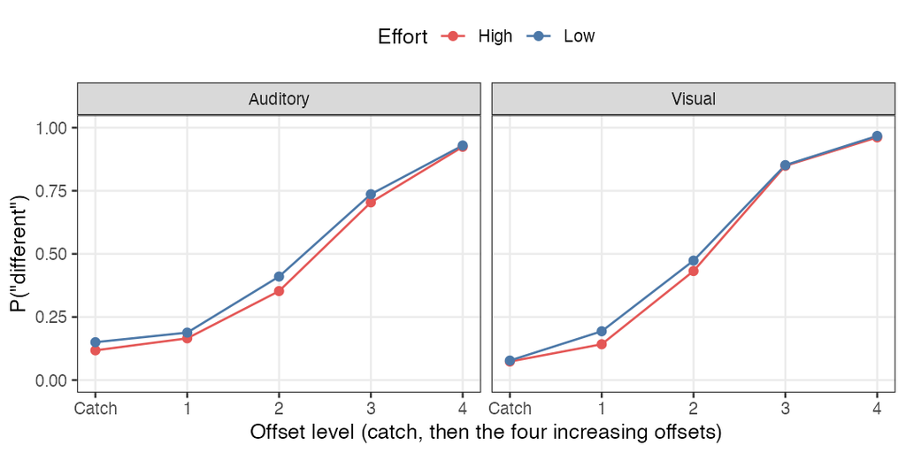

Figure 2: Observed proportion of different responses by offset and effort. Catch is the zero-offset trial. Levels 1–4 are the four increasing offsets (auditory: 8, 16, 32, and 64 Hz; visual: 0.06, 0.12, 0.24, and 0.48).

M1 was accepted with the full random-effects structure (18,266 trials, 68 participants). On the probit scale, high effort lowered the rate of “different” responses, −0.096 (SE 0.028), 95% CI [−0.152, −0.041], *p* < .001. The catch-by-effort interaction was −0.017 (SE 0.068), 95% CI [−0.151, 0.117], *p* = .802. False alarms on catch trials moved with the other offsets rather than by an extra amount. That combination, a lower “different” rate at every offset and no extra catch effect, is the pattern of a criterion shift toward “same.” It is the same direction as the threshold result in Sun et al. (2026) and as the behavioral result in Chapter 3.

The offset-by-effort interaction was positive, 0.058 (SE 0.029), 95% CI [0.002, 0.115], *p* = .044. The slope was not shallower under high effort. A positive interaction is what a probit model without a lapse term produces when the effort difference shrinks near ceiling, and the top offset is near ceiling in both tasks. That reading was not tested by refitting the model without the top offset. The interaction should not be read as a gain in sensitivity.

## 3.2 The pupil checks

During the grip, pupil diameter was higher under high effort in the point estimate, but the interval included zero: 0.138 (SE 0.109), 95% CI [−0.075, 0.352], *t*(25.2) = 1.27, *p* = .216, on 5,240 trials from 48 participants. Participants differed in that slope. The by-participant variance of the effort coefficient was 0.374. The grip-force check in Sun et al. (2026) is the manipulation check this design was built on. The pupil result does not replace it.

The TEPR mean was smaller under high effort: −0.276 (SE 0.071), 95% CI [−0.414, −0.137], *t*(33.0) = −3.91, *p* < .001. Offset and catch were −0.028, *p* = .452, and 0.067, *p* = .192. Because grip release falls inside the TEPR window, this coefficient is not a clean effect on the task-evoked response.

## 3.3 Pupil and the slope

On the same 6,299 trials, a larger pre-probe pupil was associated with a shallower slope: −0.044 (SE 0.022), 95% CI [−0.088, −0.0001], *p* = .049. The upper end of the interval is at zero for any reporting precision coarser than four decimals. The state main effect was −0.029, *p* = .209, and the catch-by-state term was 0.068, *p* = .257. This is one test named in the locked plan. It is weak evidence, and the chapter does not rest on it.

The TEPR state predicted neither the slope nor the level of “different” responses. The offset-by-state term was 0.012, 95% CI [−0.033, 0.056], *p* = .613. The state term was 0.0004, *p* = .987, and the catch-by-state term was −0.012, *p* = .853.

Table 1: Key terms from the accepted models. Estimates are on the probit scale for M1 and M4 and on the measured scale for M2 and M3. M5 is a log-odds coefficient. Intervals are Wald intervals.

| Model | Term | Estimate | SE | CI | p |
| --- | --- | --- | --- | --- | --- |
| M1 | Effort | −0.096 | 0.028 | [−0.152, −0.041] | < .001 |
| M1 | Catch x effort | −0.017 | 0.068 | [−0.151, 0.117] | = .802 |
| M1 | Offset x effort | 0.058 | 0.029 | [0.002, 0.115] | = .044 |
| M2 | Effort | 0.138 | 0.109 | [−0.075, 0.352] | = .216 |
| M3 | Effort | −0.276 | 0.071 | [−0.414, −0.137] | < .001 |
| M3 | Offset | −0.028 | 0.037 | [−0.101, 0.044] | = .452 |
| M3 | Catch | 0.067 | 0.052 | [−0.034, 0.168] | = .192 |
| M4a | Offset x pre-probe state | −0.044 | 0.022 | [−0.088, −0.0001] | = .049 |
| M4a | Pre-probe state | −0.029 | 0.023 | [−0.073, 0.016] | = .209 |
| M4a | Catch x pre-probe state | 0.068 | 0.060 | [−0.050, 0.186] | = .257 |
| M4b | Offset x TEPR state | 0.012 | 0.023 | [−0.033, 0.056] | = .613 |
| M4b | TEPR state | 0.0004 | 0.025 | [−0.048, 0.049] | = .987 |
| M4b | Catch x TEPR state | −0.012 | 0.067 | [−0.144, 0.119] | = .853 |
| M5 | Effort | 0.130 | 0.048 | [0.037, 0.224] | = .006 |

# 4 Discussion

The behavioral result is the one this chapter can stand on. High effort reduced “different” responses at every offset, in both tasks, and the catch trials moved by about the same amount. That is a criterion shift toward “same,” without a shallower slope. It agrees with the per-participant threshold result in Sun et al. (2026) and with the behavioral result in Chapter 3. The positive offset-by-effort interaction is numerically a steeper slope under high effort. Near ceiling, a probit model without a lapse term can produce that pattern from a smaller difference at the top offset. Until that model is fit, the interaction is not evidence of a sensitivity gain.

The pupil side is smaller. Diameter during the grip moved in the predicted direction and the interval included zero, with a large spread across participants. The TEPR was smaller under high effort, and the window contains the grip release, so the coefficient cannot be presented as a pure task-evoked effect. Pre-probe pupil and the slope shared a weak negative association whose interval ends at zero. The task-evoked response, whether summarized as a mean or as an area, did not track the choice. Pupil-data loss was slightly related to effort. The pupil models include effort, and the association is reported so that the sample can be read with that fact in view.

Earlier drafts of this chapter treated a tonic increase and a phasic decrease as a dissociation, and they treated a 50 ms window as the task-evoked response. Those summaries used a compressed time axis and a different trial set. They are not the results of this chapter. The question that remains is the behavioral one: effort changes how willing older adults are to call two stimuli different, and the pupil measures collected here do not show a reliable link from arousal to the slope of that function.

Two further checks were considered after these fits and were not run. One would refit M1 without the largest offset, to test the ceiling reading of the slope interaction. The other would add a descriptive sentence on grip-force adherence from Sun et al. (2026). Either check would be labeled as following the results, and neither would replace M1–M5.

# 5 Supplement

## 5.1 Area under the curve

S1 replaces the TEPR mean in M4b with the gap-respecting area. M4b’s accepted random-effects structure did not converge for that outcome (maximum absolute gradient 0.0695 against a tolerance of 0.002). The ladder was continued from that structure by dropping the offset random slope. That step was accepted (6,299 trials). The offset-by-state term was 0.017 (SE 0.022), 95% CI [−0.026, 0.060], *p* = .432. The state term was 0.002, *p* = .934, and the catch-by-state term was −0.005, *p* = .936. The area version agrees with M4b in the sense that none of these intervals excludes zero. M4b itself was not changed.

## 5.2 Behavior in the pupil subsample

S2 fits M1’s formula to the 13,655 trials from the 51 participants who contributed to the TEPR sample. The maximal model was singular, so it was not accepted. The point estimates were −0.094 for effort (*p* = .005), 0.0006 for catch-by-effort (*p* = .994), and 0.079 for offset-by-effort (*p* = .018). They are reported only to show the direction in this subset. They are not a second accepted test.

## 5.3 Optimizer check

M1, M4a, and M4b were re-estimated with the optimizers that ship with lme4 (bobyqa, Nelder_Mead, nlminbwrap, nloptwrap.NLOPT_LN_BOBYQA, nloptwrap.NLOPT_LN_NELDERMEAD). No key-term estimate from a converged optimizer differed from the accepted bobyqa estimate by more than 0.01. The largest absolute key-term deviation in that set was 0.0001.

Table 2: Fixed effects for every fitted model. S2 is included and was not accepted.

| Model | Accepted | Term | Estimate | SE | Statistic | df | CI | p |
| --- | --- | --- | --- | --- | --- | --- | --- | --- |
| M1 | TRUE | (Intercept) | 0.434 | 0.074 | 5.86 | NA | [0.289, 0.579] | < .001 |
| M1 | TRUE | catch | −1.945 | 0.108 | −18.10 | NA | [−2.156, −1.735] | < .001 |
| M1 | TRUE | x_c | 1.136 | 0.048 | 23.65 | NA | [1.042, 1.230] | < .001 |
| M1 | TRUE | effort_c | −0.096 | 0.028 | −3.39 | NA | [−0.152, −0.041] | < .001 |
| M1 | TRUE | task_c | 0.322 | 0.094 | 3.43 | NA | [0.138, 0.506] | < .001 |
| M1 | TRUE | catch:effort_c | −0.017 | 0.068 | −0.25 | NA | [−0.151, 0.117] | = .802 |
| M1 | TRUE | x_c:effort_c | 0.058 | 0.029 | 2.02 | NA | [0.002, 0.115] | = .044 |
| M1 | TRUE | catch:task_c | −0.674 | 0.072 | −9.35 | NA | [−0.815, −0.533] | < .001 |
| M1 | TRUE | x_c:task_c | 0.218 | 0.031 | 6.95 | NA | [0.157, 0.279] | < .001 |
| M1 | TRUE | effort_c:task_c | 0.050 | 0.056 | 0.89 | NA | [−0.060, 0.160] | = .374 |
| M1 | TRUE | catch:effort_c:task_c | 0.097 | 0.137 | 0.71 | NA | [−0.171, 0.365] | = .477 |
| M1 | TRUE | x_c:effort_c:task_c | 0.082 | 0.058 | 1.42 | NA | [−0.031, 0.195] | = .157 |
| M2 | TRUE | (Intercept) | −0.356 | 0.114 | −3.13 | 42.5 | [−0.578, −0.133] | = .003 |
| M2 | TRUE | effort_c | 0.138 | 0.109 | 1.27 | 25.2 | [−0.075, 0.352] | = .216 |
| M2 | TRUE | task_c | 0.036 | 0.063 | 0.57 | 4498.0 | [−0.088, 0.161] | = .567 |
| M2 | TRUE | effort_c:task_c | −0.120 | 0.119 | −1.01 | 1143.0 | [−0.354, 0.114] | = .315 |
| M3 | TRUE | (Intercept) | 0.918 | 0.115 | 7.96 | 50.7 | [0.692, 1.145] | < .001 |
| M3 | TRUE | effort_c | −0.276 | 0.071 | −3.91 | 33.0 | [−0.414, −0.137] | < .001 |
| M3 | TRUE | task_c | −0.200 | 0.050 | −4.03 | 6028.0 | [−0.297, −0.103] | < .001 |
| M3 | TRUE | catch | 0.067 | 0.052 | 1.31 | 6144.0 | [−0.034, 0.168] | = .192 |
| M3 | TRUE | x_c | −0.028 | 0.037 | −0.76 | 26.1 | [−0.101, 0.044] | = .452 |
| M3 | TRUE | effort_c:task_c | 0.132 | 0.089 | 1.47 | 1397.0 | [−0.044, 0.307] | = .141 |
| M4a | TRUE | (Intercept) | 0.444 | 0.096 | 4.62 | NA | [0.256, 0.633] | < .001 |
| M4a | TRUE | catch | −2.129 | 0.181 | −11.76 | NA | [−2.484, −1.774] | < .001 |
| M4a | TRUE | x_c | 1.073 | 0.051 | 20.92 | NA | [0.972, 1.173] | < .001 |
| M4a | TRUE | b1_state | −0.029 | 0.023 | −1.26 | NA | [−0.073, 0.016] | = .209 |
| M4a | TRUE | effort_c | −0.073 | 0.049 | −1.51 | NA | [−0.168, 0.022] | = .132 |
| M4a | TRUE | task_c | 0.368 | 0.058 | 6.38 | NA | [0.255, 0.481] | < .001 |
| M4a | TRUE | b1_trait | 0.009 | 0.068 | 0.14 | NA | [−0.124, 0.143] | = .891 |
| M4a | TRUE | catch:b1_state | 0.068 | 0.060 | 1.13 | NA | [−0.050, 0.186] | = .257 |
| M4a | TRUE | catch:effort_c | −0.199 | 0.127 | −1.56 | NA | [−0.449, 0.051] | = .119 |
| M4a | TRUE | catch:task_c | −0.756 | 0.156 | −4.85 | NA | [−1.062, −0.451] | < .001 |
| M4a | TRUE | x_c:b1_state | −0.044 | 0.022 | −1.97 | NA | [−0.088, −0.0001] | = .049 |
| M4a | TRUE | x_c:effort_c | 0.090 | 0.050 | 1.82 | NA | [−0.007, 0.188] | = .069 |
| M4a | TRUE | x_c:task_c | 0.219 | 0.057 | 3.84 | NA | [0.107, 0.331] | < .001 |
| M4b | TRUE | (Intercept) | 0.447 | 0.094 | 4.74 | NA | [0.262, 0.632] | < .001 |
| M4b | TRUE | catch | −2.125 | 0.182 | −11.70 | NA | [−2.482, −1.769] | < .001 |
| M4b | TRUE | x_c | 1.070 | 0.051 | 20.99 | NA | [0.970, 1.170] | < .001 |
| M4b | TRUE | tepr_state | 0.0004 | 0.025 | 0.02 | NA | [−0.048, 0.049] | = .987 |
| M4b | TRUE | effort_c | −0.078 | 0.049 | −1.61 | NA | [−0.174, 0.017] | = .108 |
| M4b | TRUE | task_c | 0.400 | 0.058 | 6.83 | NA | [0.285, 0.514] | < .001 |
| M4b | TRUE | tepr_trait | 0.151 | 0.051 | 2.99 | NA | [0.052, 0.251] | = .003 |
| M4b | TRUE | catch:tepr_state | −0.012 | 0.067 | −0.19 | NA | [−0.144, 0.119] | = .853 |
| M4b | TRUE | catch:effort_c | −0.190 | 0.128 | −1.49 | NA | [−0.441, 0.061] | = .137 |
| M4b | TRUE | catch:task_c | −0.764 | 0.156 | −4.89 | NA | [−1.070, −0.458] | < .001 |
| M4b | TRUE | x_c:tepr_state | 0.012 | 0.023 | 0.51 | NA | [−0.033, 0.056] | = .613 |
| M4b | TRUE | x_c:effort_c | 0.086 | 0.050 | 1.72 | NA | [−0.012, 0.184] | = .085 |
| M4b | TRUE | x_c:task_c | 0.212 | 0.057 | 3.72 | NA | [0.100, 0.324] | < .001 |
| M5 | TRUE | (Intercept) | −0.408 | 0.421 | −0.97 | NA | [−1.232, 0.417] | = .333 |
| M5 | TRUE | effort_c | 0.130 | 0.048 | 2.73 | NA | [0.037, 0.224] | = .006 |
| M5 | TRUE | task_c | 0.649 | 0.051 | 12.62 | NA | [0.548, 0.750] | < .001 |
| M5 | TRUE | catch | 0.033 | 0.059 | 0.56 | NA | [−0.083, 0.149] | = .577 |
| M5 | TRUE | x_c | 0.045 | 0.024 | 1.87 | NA | [−0.002, 0.092] | = .062 |
| M5 | TRUE | effort_c:task_c | −0.052 | 0.095 | −0.54 | NA | [−0.239, 0.135] | = .589 |
| S1 | TRUE | (Intercept) | 0.429 | 0.094 | 4.55 | NA | [0.244, 0.613] | < .001 |
| S1 | TRUE | catch | −2.096 | 0.176 | −11.93 | NA | [−2.441, −1.752] | < .001 |
| S1 | TRUE | x_c | 1.040 | 0.026 | 39.49 | NA | [0.989, 1.092] | < .001 |
| S1 | TRUE | teprauc_state | 0.002 | 0.024 | 0.08 | NA | [−0.044, 0.048] | = .934 |
| S1 | TRUE | effort_c | −0.079 | 0.048 | −1.65 | NA | [−0.173, 0.015] | = .099 |
| S1 | TRUE | task_c | 0.399 | 0.057 | 7.01 | NA | [0.287, 0.510] | < .001 |
| S1 | TRUE | teprauc_trait | 0.153 | 0.051 | 3.02 | NA | [0.054, 0.252] | = .003 |
| S1 | TRUE | catch:teprauc_state | −0.005 | 0.065 | −0.08 | NA | [−0.132, 0.122] | = .936 |
| S1 | TRUE | catch:effort_c | −0.187 | 0.128 | −1.46 | NA | [−0.437, 0.064] | = .144 |
| S1 | TRUE | catch:task_c | −0.768 | 0.155 | −4.95 | NA | [−1.072, −0.464] | < .001 |
| S1 | TRUE | x_c:teprauc_state | 0.017 | 0.022 | 0.79 | NA | [−0.026, 0.060] | = .432 |
| S1 | TRUE | x_c:effort_c | 0.079 | 0.049 | 1.63 | NA | [−0.016, 0.174] | = .103 |
| S1 | TRUE | x_c:task_c | 0.255 | 0.050 | 5.07 | NA | [0.156, 0.353] | < .001 |
| S2 | FALSE | (Intercept) | 0.466 | 0.090 | 5.18 | NA | [0.290, 0.642] | < .001 |
| S2 | FALSE | catch | −2.014 | 0.126 | −15.94 | NA | [−2.262, −1.766] | < .001 |
| S2 | FALSE | x_c | 1.145 | 0.054 | 21.32 | NA | [1.039, 1.250] | < .001 |
| S2 | FALSE | effort_c | −0.094 | 0.033 | −2.81 | NA | [−0.159, −0.028] | = .005 |
| S2 | FALSE | task_c | 0.352 | 0.097 | 3.61 | NA | [0.161, 0.542] | < .001 |
| S2 | FALSE | catch:effort_c | 0.0006 | 0.081 | 0.01 | NA | [−0.157, 0.159] | = .994 |
| S2 | FALSE | x_c:effort_c | 0.079 | 0.034 | 2.36 | NA | [0.013, 0.145] | = .018 |
| S2 | FALSE | catch:task_c | −0.736 | 0.085 | −8.64 | NA | [−0.904, −0.569] | < .001 |
| S2 | FALSE | x_c:task_c | 0.239 | 0.037 | 6.52 | NA | [0.167, 0.311] | < .001 |
| S2 | FALSE | effort_c:task_c | 0.052 | 0.066 | 0.79 | NA | [−0.077, 0.180] | = .432 |
| S2 | FALSE | catch:effort_c:task_c | −0.007 | 0.161 | −0.04 | NA | [−0.323, 0.309] | = .965 |
| S2 | FALSE | x_c:effort_c:task_c | 0.066 | 0.067 | 0.99 | NA | [−0.065, 0.198] | = .323 |

## 6 References

Allaire, J., Xie, Y., Dervieux, C., McPherson, J., Luraschi, J., Ushey, K., Atkins, A., Wickham, H., Cheng, J., Chang, W., & Iannone, R. (2022). *Quarto*. https://quarto.org

Aston-Jones, G., & Cohen, J. D. (2005). An integrative theory of locus coeruleus–norepinephrine function: Adaptive gain and optimal performance. *Annual Review of Neuroscience*, *28*, 403–450. https://doi.org/10.1146/annurev.neuro.28.061604.135709

Bates, D., Mächler, M., Bolker, B., & Walker, S. (2015). Fitting linear mixed-effects models using lme4. *Journal of Statistical Software*, *67*(1), 1–48. https://doi.org/10.18637/jss.v067.i01

Beatty, J. (1982). Task-evoked pupillary responses, processing load, and the structure of processing resources. *Psychological Bulletin*, *91*(2), 276–292. https://doi.org/10.1037/0033-2909.91.2.276

Brainard, D. H. (1997). The psychophysics toolbox. *Spatial Vision*, *10*(4), 433–436. https://doi.org/10.1163/156856897X00357

Kuznetsova, A., Brockhoff, P. B., & Christensen, R. H. B. (2017). lmerTest package: Tests in linear mixed effects models. *Journal of Statistical Software*, *82*(13), 1–26. https://doi.org/10.18637/jss.v082.i13

Macmillan, N. A., & Creelman, C. D. (2005). *Detection theory: A user’s guide*.

Pashler, H. (1994). Dual-task interference in simple tasks: Data and theory. *Psychological Bulletin*, *116*(2), 220.

Prins, N. et al. (2016). *Psychophysics: A practical introduction*. Academic Press.

R Core Team. (2025). *R: A language and environment for statistical computing*. R Foundation for Statistical Computing. https://www.R-project.org/

Salthouse, T. A. (1996). The processing-speed theory of adult age differences in cognition. *Psychological Review*, *103*(3), 403–428. https://doi.org/10.1037/0033-295X.103.3.403

Sun, A. Y., Dastgheib, M., Hu, X., Bennett, I. J., Zhang, W., Maniscalco, B., Peters, M. A. K., & Seitz, A. R. (2026). *Effects of handgrip effort on perceptual judgments and metacognitive performance in older adults*. PsyArXiv. https://osf.io/preprints/psyarxiv/wjerv_v1

Verhaeghen, P., Steitz, D. W., Sliwinski, M. J., & Cerella, J. (2003). Aging and dual-task performance: A meta-analysis. *Psychology and Aging*, *18*(3), 443–460. https://doi.org/10.1037/0882-7974.18.3.443

Wickens, C. D. (2008). Multiple resources and mental workload. *Human Factors*, *50*(3), 449–455. https://doi.org/10.1518/001872008X288394